# Open Data Notebooks 2017-02A :: ODN2017-02A

## Case Study: Commissioner for Information of Public Importance and Personal Data Protection, Republic of Serbia: “Complaints in The Field of Freedom of Information” Data Set

### Part A: Import, clean up, and translate to English

#### Data Set: zalbepristup.csv

#### Source: data.gov.rs

#### Accessed on 05 Feb 2017 from [data.gov.rs/sr/datasets/](http://data.gov.rs/sr/datasets/zalbe-iz-oblasti-prava-na-pristup-informacijama/)

#### Description: Complaints in The Field of Freedom of Information

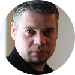

**Author:** Goran S. Milovanovic, Data Science Serbia

**Notebook:** 02/05/2017, Belgrade, Serbia

The notebook focuses on an exploratory analysis of the open data set on the *Complaints in the field of freedom of information*, provided at the [Open Data Portal of the Republic of Serbia](http://data.gov.rs/sr/) *that is currently under development*. The data set was kindly provided to the Open Data Portal by the [Commissioner for Information of Public Importance and Personal Data Protection](http://www.poverenik.rs/en.html) of the Republic of Serbia. Many more open data sets will be indexed and uploaded to the [Open Data Portal of the Republic of Serbia](http://data.gov.rs/sr/) in the forthcoming weeks and months.

As of the data set: (a) no metadata were provided; (b) the translation of legal terms from Serbian to English is mine, meaning: a lot of Google Translate suggestions were used (I’m a psychologists, not a lawyer or a legal expert); (c) mixture of latin and cyrilic alphabet was detected in the data; (d) thorough cleaning takes place here, in Part A; exploratory analysis + data visualizations will be presented soon (Part B).

**Disclaimer.** The [Open Data Portal of the Republic of Serbia](http://data.gov.rs/sr/) is a young initiative that is currently under development. Neither the owner of this GitHub account as an individual, or Data Science Serbia as an organization, hold any responsibility for the changes in the URLs of the data sets, or the changes in the content of the data sets published on the [Open Data Portal of the Republic of Serbia](http://data.gov.rs/sr/). The results of the exploratory analyses and statistical models that are presented on this GitHub account are developed for illustrative purposes only, having in mind the goal of popularization of Open Data exclusively. The owner of this GitHub account strongly advises to consult him (e-mail: goran.s.milovanovic@gmail.com and Data Science Serbia before using the results presented here in public debate or media, and/or for any purposes other than motivating the usage and development of Open Data.

### 1. Setup

Load libraries + raw data:

```r
rm(list = ls())
library(dplyr)
library(tidyr)
library(stringr)
library(knitr)

### --- Working Directory
wDir <- '../ComInfoPublicImportance'
setwd(wDir)

### --- Load Raw Data Set
fileLoc <- 'zalbepristup.csv'
rawData <- read.table(fileLoc,
                      header = T,
                      sep = "|",
                      check.names = F,
                      stringsAsFactors = F)

### --- Inspect Data Set
dim(rawData)
```

```
## [1] 27518    16
```

There are 27518 row entires and 16 variables; Take a sneak peek at the data set:

```r
glimpse(rawData)
```

```
## Observations: 27,518
## Variables: 16
## $ Code            <chr> "071-01-340/2017-03", "071-01-339/2017-03", "0...
## $ CreateDate      <chr> "2017-01-30", "2017-01-30", "2017-01-30", "201...
## $ ArticalType     <chr> "Žalba", "Žalba", "Žalba", "Žalba", "Žalba", "...
## $ ApplicantGroup  <chr> "Građani", "Mediji", "Građani", "Građani", "Gr...
## $ ApplicantCity   <chr> "Loznica", "BEOGRAD", "Beograd", "Beograd", "B...
## $ ArticalStatus   <chr> "Активан", "Активан", "Активан", "Активан", "А...
## $ Authority       <chr> "Ministarstvo pravde ", "Srbijašume JP ", "Pre...
## $ AuthorityGroup  <chr> "Ministarstva", "Republička javna preduzeća", ...
## $ AuthorityCity   <chr> "Beograd", "Beograd", "Beograd", "Beograd", "B...
## $ BasicOfStarting <chr> "Žalba na odgovor", "Žalba na odgovor", "Žalba...
## $ Reason          <chr> "No data", "No data", "No data", "No data", "N...
## $ Decision        <chr> "No data", "No data", "No data", "No data", "N...
## $ Outcome         <chr> "No data", "No data", "No data", "No data", "N...
## $ Oblast          <chr> "Postupci organa uprave,", "Budžet (plate, don...
## $ DecisionDate    <chr> "1900-01-01", "1900-01-01", "1900-01-01", "190...
## $ OutcomeDate     <chr> "1900-01-01", "1900-01-01", "1900-01-01", "190...
```

### Recoding: translate to English and check for consistency

The `Code` column is most probably the unique ID of the complaint; check for consistency:

```r
sum(duplicated(rawData$Code))
```

```
## [1] 23
```

There are 23 duplicated `Code` values (complaint IDs, presumeably); checking it out:

```r
duplicatedCodes <- rawData$Code[which(duplicated(rawData$Code))]
duplicatedCodes
```

```
##  [1] "07-00-02845/2016-03" "07-00-02806/2016-03" "07-00-02790/2016-03"
##  [4] "07-00-02789/2016-03" "07-00-02785/2016-03" "07-00-02694/2016-03"
##  [7] "07-00-02688/2016-03" "07-00-02665/2016-03" "07-00-02664/2016-03"
## [10] "07-00-02663/2016-03" "07-00-02645/2016-03" "07-00-02630/2016-03"
## [13] "07-00-02617/2016-03" "07-00-02607/2016-03" "07-00-02592/2016-03"
## [16] "07-00-02574/2016-03" "07-00-02558/2016-03" "07-00-02545/2016-03"
## [19] "07-00-02542/2016-03" "07-00-02526/2016-03" "07-00-02397/2016-03"
## [22] "07-00-02310/2016-03" "07-00-02084/2016-03"
```

Inspect the `ArticalStatus` value of the duplicated entries:

```r
duplicatedCodes <- rawData$Code[which(duplicated(rawData$Code))]
inspectDuplicates <- rawData[rawData$Code %in% duplicatedCodes, ]
inspectDuplicates$ArticalStatus
```

```
##  [1] "Активан" "Активан" "Активан" "Активан" "Активан" "Активан" "Активан"
##  [8] "Активан" "Активан" "Активан" "Активан" "Активан" "Активан" "Активан"
## [15] "Активан" "Активан" "Активан" "Активан" "Активан" "Активан" "Активан"
## [22] "Активан" "Активан" "Активан" "Активан" "Активан" "Активан" "Активан"
## [29] "Активан" "Активан" "Активан" "Активан" "Активан" "Активан" "Активан"
## [36] "Активан" "Активан" "Активан" "Активан" "Активан" "Активан" "Активан"
## [43] "Активан" "Активан" "Активан" "Активан"
```

`"Активан"` means `Active` in Serbian; inspect the `CreateDate` field:

```r
inspectDuplicates$CreateDate
```

```
##  [1] "2016-08-05" "2016-08-05" "2016-08-01" "2016-08-01" "2016-07-29"
##  [6] "2016-07-29" "2016-07-29" "2016-07-29" "2016-07-29" "2016-07-29"
## [11] "2016-07-21" "2016-07-21" "2016-07-20" "2016-07-20" "2016-07-19"
## [16] "2016-07-19" "2016-07-19" "2016-07-19" "2016-07-19" "2016-07-19"
## [21] "2016-07-18" "2016-07-18" "2016-07-18" "2016-07-18" "2016-07-15"
## [26] "2016-07-15" "2016-07-15" "2016-07-15" "2016-07-14" "2016-07-14"
## [31] "2016-07-13" "2016-07-13" "2016-07-12" "2016-07-12" "2016-07-11"
## [36] "2016-07-11" "2016-07-11" "2016-07-11" "2016-07-08" "2016-07-08"
## [41] "2016-06-29" "2016-06-29" "2016-06-21" "2016-06-21" "2016-06-06"
## [46] "2016-06-06"
```

Almost all duplicated `Code` values refer to recently filed and still active complaints; we will assume that complaint procedure is still under way and/or the database was not updated or made consistent in respect to the must recent changes and delete them.

```r
rawData <- rawData[-which(rawData$Code %in% duplicatedCodes), ]
dim(rawData)
```

```
## [1] 27472    16
```

We are now left with 27472 row entries in the table.

```r
table(rawData$ArticalType)
```

```
##
## Žalba
## 27472
```

`Žalba` means `Complaint` in Serbian; thus, nothing informative here: delete `ArticleType`:

```r
rawData$ArticalType <- NULL
```

```r
table(rawData$ApplicantGroup)
```

```
##
##                                              Advokati
##                                                   346
##                                               Građani
##                                                 17994
##                                                 Medij
##                                                     1
##                                                Mediji
##                                                  1766
##                                 NVO i druga udruženja
##                                                  5254
##                                         Organi Vlasti
##                                                   561
##                                                Ostali
##                                                   510
##                                     Političke Stranke
##                                                   496
## Republičke agencije, direkcije, zavodi, fondovi i dr.
##                                                     2
##                                             Sindikati
##                                                   535
##                                 Sportske organizacije
##                                                     4
##              Ustanove osnovnog i srednjeg obrazovanja
##                                                     1
##                            Ustanove socijalne zaštite
##                                                     1
##                          Ustanove u oblasti zdravstva
##                                                     1
```

Translate `ApplicantGroup` to English:

```r
rawData$ApplicantGroup <- recode(rawData$ApplicantGroup,
                                 Advokati = "Lawyers",
                                 Građani = "Citizens",
                                 Medij = "Media",
                                 Mediji = "Media",
                                 `NVO i druga udruženja` = "NGO/OtherOrgs",
                                 `Organi Vlasti` = "Government Agencies",
                                 Ostali = "Other",
                                 `Političke Stranke` = "Political Parties",
                                 `Republičke agencije, direkcije, zavodi, fondovi i dr.` = "Republic Institutions - Various",
                                 `Sindikati` = "Labor Unions",
                                 `Sportske organizacije` = "Sport Orgs",
                                 `Ustanove osnovnog i srednjeg obrazovanja` = "Elemenatary and High School Education Institutions",
                                 `Ustanove socijalne zaštite` = "Social Welfare Institutions",
                                 `Ustanove u oblasti zdravstva` = "Public Health Instituions"
                                 )
```

Check:

```r
table(rawData$ApplicantGroup)
```

```
##
##                                           Citizens
##                                              17994
## Elemenatary and High School Education Institutions
##                                                  1
##                                Government Agencies
##                                                561
##                                       Labor Unions
##                                                535
##                                            Lawyers
##                                                346
##                                              Media
##                                               1767
##                                      NGO/OtherOrgs
##                                               5254
##                                              Other
##                                                510
##                                  Political Parties
##                                                496
##                          Public Health Instituions
##                                                  1
##                    Republic Institutions - Various
##                                                  2
##                        Social Welfare Institutions
##                                                  1
##                                         Sport Orgs
##                                                  4
```

`Applicant City`:

```r
length(unique(rawData$ApplicantCity))
```

```
## [1] 552
```

Recode `Nepoznat` (`Unknown` in English) from `ApplicantCity` to `NA`:

```r
rawData$ApplicantCity[rawData$ApplicantCity == 'Nepoznat'] <- NA
sum(is.na(rawData$ApplicantCity))
```

```
## [1] 13
```

Fix city names in `ApplicantCity`:

```r
rawData$ApplicantCity <- str_to_title(rawData$ApplicantCity)
unique(sort(rawData$ApplicantCity))
```

```
##   [1] "Ada"                         "Aleksandrovac"
##   [3] "Aleksinac"                   "Alibunar"
##   [5] "Apatin"                      "Aradac"
##   [7] "Aranđelovac"                 "Arandjеlovac"
##   [9] "Arilje"                      "Ariljе"
##  [11] "Azbresnica"                  "Babušnica"
##  [13] "Bač"                         "Baćevac"
##  [15] "Bačka Palanka"               "Bačka Topola"
##  [17] "Bački Jarak"                 "Bački Petrovac"
##  [19] "Bački  Pеtrovac"             "Bačko Dobro Polje"
##  [21] "Bačko Gradište"              "Bačko Petrovo Selo"
##  [23] "Bajina Bašta"                "Bajmok"
##  [25] "Bajmok "                     "Banarski Dvor"
##  [27] "Banatski Brestovac"          "Banatski Despotovac"
##  [29] "Banatski Dvor"               "Banatski Karlovac"
```

[output cut: 258 more lines]

Some complaints originate from foreign countries (e.g. `Zagreb, Hrvatska`, `Švedska`, `Sidnej`, `Kanada`, `Velika Britanija`, `Švajcarska`, `Beč, Austrija`, `Kopenhagen, Danska`, `Hrvatska`, etc.). Also, some entries are really duplicates as a consequence of presence of Serbian language-specific characters (e.g. `Aranđelovac` and `Arandjelovac`). We will attempt to organize the information from the `ApplicantCity` column in the following way:

- determine whether the `ApplicantCity` is in Serbia or not; introduce a new `logical` column `ApplicantCityForeign` (`TRUE` for cities outside of Serbia, `FALSE` otherwise);
- determine whether the entry in the `ApplicantCity` column contains (a) only the name of applicant’s city, or (b) a combination of city and country names (e.g. `Beč, Austrija`); introduce a new column `ApplicantCityOnly` as `character` where `City` stands for city only information, `CountryAndCity` for a combination of city and country name, and `Country` for the presence of a country name only.
- determine whether the entry in the `ApplicantCity` column contains (a) only the name of applicant’s city, or (b) a combination of city and country names (e.g. `Beč, Austrija`); introduce a new column `ApplicantCityOnly` as `character` where `City` stands for city only information, `CountryAndCity` for a combination of city and country name, and `Country` the presence of a country name only.

These tasks will be carried out manually, by inspecting all distinct row entries in the `ApplicantCity` column one by one. One assumption can be made: where `,` is present in the `ApplicantCity` column, it most probably separates a city and a country name, indicating `TRUE` in the `ApplicantCityForeign` column and `FALSE` in the `ApplicantCityOnly` column.

```r
commaEntries <- which(grepl(",", rawData$ApplicantCity))
unique(rawData$ApplicantCity[commaEntries])
```

```
##  [1] "Melburn, Australija"      "Zagreb, Hrvatska"
##  [3] "Ljubljana, Slovenija"     "Beč, Austrija"
##  [5] "Brčko, Bih"               "Budimpešta, Mađarska"
##  [7] "Kopenhagen, Danska"       "Bon, Nemačka"
##  [9] "Podgorica, Crna Gora"     "Helzinburg, Švedska"
## [11] "Nemačka, Bon"             "Kozluk, Republika Srpska"
```

All these entries are foreign cities.

```r
# - fix typos and unsystematic errors:
rawData$ApplicantCity[which(grepl("Pančevo|Pančеvo", rawData$ApplicantCity))] <- "Pančevo"
rawData$ApplicantCity[which(grepl("Beč Austrija", rawData$ApplicantCity, fixed = T))] <- "Beč, Austrija"
rawData$ApplicantCity[which(grepl("Bosna I Hercegovina", rawData$ApplicantCity, fixed = T))] <- "Bosna i Hercegovina"
rawData$ApplicantCity[which(grepl("Florida Usa", rawData$ApplicantCity, fixed = T))] <- "Florida, USA"
rawData$ApplicantCity[which(grepl("Strasswalcen/Austija", rawData$ApplicantCity, fixed = T))] <- "Strasswalcen, Austrija"
rawData$ApplicantCity[which(grepl("Gornij Milanovac", rawData$ApplicantCity, fixed = T))] <- "Gornji Milanovac"
rawData$ApplicantCity[which(grepl("Arandjelovac", rawData$ApplicantCity, fixed = T))] <- "Aranđelovac"
# - introduce rawData$ApplicantCityOnly and rawData$ApplicantCityForeign fields:
rawData$ApplicantCityOnly <- rep("City", dim(rawData)[1])
rawData$ApplicantCityOnly[commaEntries] <- 'CountryAndCity'
countriesFound <- c('Brazil', 'Britanska Devičanska Ostrva', 'Hrvatska', 'Kanada', 'Makedonija', 'Poljska', 'Republika Ekvador', 'Švajcarska', 'Švedska', 'Velika Britanija')
foreignCitiesFound <- c('Beč', 'Brčko', 'Budimpešta', 'Ljubljana' , 'Mostar', 'Sidnej')
foreignCities <- unlist(lapply(foreignCitiesFound, function(x) {
  which(grepl(x, rawData$ApplicantCity, fixed = T))}))
rawData$ApplicantCityForeign <- rep(F, dim(rawData)[1])
rawData$ApplicantCityForeign[commaEntries] <- T
rawData$ApplicantCityForeign[foreignCities] <- T
foreignCountries <- unlist(lapply(countriesFound, function(x) {
  which(grepl(x, rawData$ApplicantCity, fixed = T))}))
rawData$ApplicantCityForeign[foreignCountries] <- T
rawData$ApplicantCityOnly[foreignCountries] <- 'Country'
rawData$ApplicantCityOnly[which(grepl("No Data", rawData$ApplicantCityOnly))] <- NA
table(rawData$ApplicantCityOnly, rawData$ApplicantCityForeign)
```

```
##
##                  FALSE  TRUE
##   City           27247   182
##   Country            0    21
##   CountryAndCity     0    22
```

**Hopefully**, these operations have removed all potential confusions and errors from the `ApplicantCity` column.

```r
table(rawData$ArticalStatus)
```

```
##
##   Активан Архивиран   Завршен
##      4133     20079      3260
```

Translate `ArticleStatus` to English:

```r
rawData$ArticalStatus <- recode(rawData$ArticalStatus,
                                Активан = "Active",
                                Архивиран = "Archived",
                                Завршен = "Completed")
# Percentage:
articalTypes <- names(table(rawData$ArticalStatus))
percents <- paste0(round((table(rawData$ArticalStatus)/length(rawData$ArticalStatus))*100, 2), "%")
names(percents) <- articalTypes
percents
```

```
##    Active  Archived Completed
##  "15.04%"  "73.09%"  "11.87%"
```

Inspect `AuthorityGroup`:

```r
table(rawData$AuthorityGroup)
```

```
##
##                                                              Građani
##                                                                    1
##                         Gradski i opštinski organi i mesne zajednice
##                                                                 2111
##                                                      Javna preduzeća
##                                                                 2184
##                 Javne službe i druge organizacije lokalne samouprave
##                                                                  257
##                                              Lokalna javna preduzeća
##                                                                  828
##                                                               Mediji
##                                                                    3
##                                                         Ministarstva
##                                                                 1841
##                                                       Najviši organi
##                                                                  106
##                                      Nezavisni državni organi i tela
##                                                                  238
##                                                              No data
##                                                                   25
##                                                NVO i druga udruženja
##                                                                    8
##                                            Organi lokalne samouprave
##                                                                 4229
##                                                        Organi Vlasti
##                                                                   44
##                                                               Ostali
##                                                                  336
##                                                   Pokrajinski organi
##                                                                  229
##                                                    Pravosudni organi
##                                                                 3633
##                                           Republička javna preduzeća
##                                                                  549
##                Republičke agencije, direkcije, zavodi, fondovi i dr.
##                                                                 1351
##                                                    Republički organi
##                                                                 7989
##                                                            Sindikati
##                                                                    2
##                                                Sportske organizacije
##                                                                   46
##                             Ustanove osnovnog i srednjeg obrazovanja
##                                                                  304
##                                           Ustanove socijalne zaštite
##                                                                  204
##                     Ustanove u oblasti nauke, kulture i informisanja
##                                                                  124
##                                       Ustanove u oblasti obrazovanja
##                                                                   20
##                                           Ustanove u oblasti odbrane
##                                                                    4
##                                         Ustanove u oblasti pravosuđa
##                                                                  130
## Ustanove u oblasti privrede, poljoprivrede, šumarstva i vodoprivrede
##                                                                   69
##                                         Ustanove u oblasti zdravstva
##                                                                  374
##                                         Ustanove visokog obrazovanja
##                                                                  233
```

Translate `AuthorityGroup` to English:

```r
rawData$AuthorityGroup <- recode(rawData$AuthorityGroup,
                                 Građani = "Citizens",
                                 `Gradski i opštinski organi i mesne zajednice` = "City and Municipality Agencies, Community Centers",
                                 `Javna preduzeća` = "Public Companies",
                                 `Javne službe i druge organizacije lokalne samouprave` = "Public Departments and Other Organizations of Local Self-Government",
                                 `Lokalna javna preduzeća` = "Local Public Companies",
                                 `Mediji` = "Media",
                                 `Ministarstva` = "Ministries",
                                 `Najviši organi` = "Highest Agencies",
                                 `Nezavisni državni organi i tela` = "Independent Government Agencies and Bodies",
                                 `NVO i druga udruženja` = "NGO/OtherOrgs",
                                 `Organi lokalne samouprave` = "Local Self-Government Agencies",
                                 `Organi Vlasti` = "Government Agencies",
                                 `Ostali` = "Other",
                                 `Pokrajinski organi` = "Province Agencies",
                                 `Pravosudni organi` = "Juridical Agencies",
                                 `Republička javna preduzeća` = "Republic Public Companies",
                                 `Republičke agencije, direkcije, zavodi, fondovi i dr.` = "Republic Institutions - Various",
                                 `Republički organi` = "Republic Agencies",
                                 `Sindikati` = "Labor Unions",
                                 `Sportske organizacije` = "Sport Orgs",
                                 `Ustanove osnovnog i srednjeg obrazovanja` = "Elemenatary and High School Education Institutions",
                                 `Ustanove socijalne zaštite` = "Social Welfare Institutions",
                                 `Ustanove u oblasti nauke, kulture i informisanja` = "Science, Culture, and Information Institutions",
                                 `Ustanove u oblasti obrazovanja` = "Education Institutions",
                                 `Ustanove u oblasti odbrane` = "Defense Institutions",
                                 `Ustanove u oblasti pravosuđa` = "Juridical Institutions",
                                 `Ustanove u oblasti privrede, poljoprivrede, šumarstva i vodoprivrede` = "Economy, Agriculture, Forestry, and Water Management Institutions",
                                 `Ustanove u oblasti zdravstva` = "Public Health Institutions",
                                 `Ustanove visokog obrazovanja` = "Higher Education Institutions"
                                 )
```

Check `AuthorityGroup`:

```r
table(rawData$AuthorityGroup)
```

```
##
##                                                            Citizens
##                                                                   1
##                   City and Municipality Agencies, Community Centers
##                                                                2111
##                                                Defense Institutions
##                                                                   4
##   Economy, Agriculture, Forestry, and Water Management Institutions
##                                                                  69
##                                              Education Institutions
##                                                                  20
##                  Elemenatary and High School Education Institutions
##                                                                 304
##                                                 Government Agencies
##                                                                  44
##                                       Higher Education Institutions
##                                                                 233
##                                                    Highest Agencies
##                                                                 106
##                          Independent Government Agencies and Bodies
##                                                                 238
##                                                  Juridical Agencies
##                                                                3633
##                                              Juridical Institutions
##                                                                 130
##                                                        Labor Unions
##                                                                   2
##                                              Local Public Companies
##                                                                 828
##                                      Local Self-Government Agencies
##                                                                4229
##                                                               Media
##                                                                   3
##                                                          Ministries
##                                                                1841
##                                                       NGO/OtherOrgs
##                                                                   8
##                                                             No data
##                                                                  25
##                                                               Other
##                                                                 336
##                                                   Province Agencies
##                                                                 229
##                                                    Public Companies
##                                                                2184
## Public Departments and Other Organizations of Local Self-Government
##                                                                 257
##                                          Public Health Institutions
##                                                                 374
##                                                   Republic Agencies
##                                                                7989
##                                     Republic Institutions - Various
##                                                                1351
##                                           Republic Public Companies
##                                                                 549
##                      Science, Culture, and Information Institutions
##                                                                 124
##                                         Social Welfare Institutions
##                                                                 204
##                                                          Sport Orgs
##                                                                  46
```

Inspect `AuthorityCity`:

```r
rawData$AuthorityGroup[rawData$AuthorityGroup == 'No data'] <- NA
length(unique((rawData$AuthorityCity)))
```

```
## [1] 350
```

Recode `Nepoznat` (`Unknown` in English) from `AuthorityCity` to `NA`:

```r
rawData$AuthorityCity[rawData$AuthorityCity == 'Nepoznat'] <- NA
sum(is.na(rawData$AuthorityCity))
```

```
## [1] 1
```

```r
rawData$AuthorityCity[rawData$AuthorityCity == 'No data'] <- NA
```

Fix city names in `AuthorityCity` and check:

```r
rawData$AuthorityCity <- str_to_title(rawData$AuthorityCity)
unique(rawData$AuthorityCity)
```

```
##   [1] "Beograd"                   "Zaječar"
##   [3] "Novi Sad"                  "Vrbas"
##   [5] "Vranje"                    "Smederevo"
##   [7] "Kovačica"                  "Leskovac"
##   [9] "Gornji Milanovac"          "Subotica"
##  [11] "Leposavić"                 "Niš"
##  [13] "Sirogojno"                 "Koceljeva"
##  [15] "Pirot"                     "Novi Pazar"
##  [17] "Jagodina"                  "Negotin"
##  [19] "Bečej"                     "Kosjerić"
##  [21] "Prijepolje"                "Ljig"
##  [23] "Prijеpoljе"                "Pančеvo"
##  [25] "Vrnjačka Banja"            "Knić"
##  [27] "Medveđa"                   "Odžaci"
##  [29] "Sombor"                    "Paraćin"
```

[output cut: 158 more lines]

Ok, all these seem to be Serbian cities. Inspect `BasicOfStarting`:

```r
table(rawData$BasicOfStarting)
```

```
##
##                                   No data
##                                         3
##                   Žalba na ćutanje uprave
##                                     21412
## Žalba na obaveštenje sa elementima odluke
##                                       532
##                          Žalba na odgovor
##                                      3897
##              Žalba na zakljucak i rešenje
##                                      1628
```

```r
rawData$BasicOfStarting <- recode(rawData$BasicOfStarting,
                                  `Žalba na ćutanje uprave` = "Silence of authority",
                                  `Žalba na obaveštenje sa elementima odluke` = "Complaint on information w. elements of decision",
                                  `Žalba na odgovor` = "Complaint on response",
                                  `Žalba na zakljucak i rešenje` = "Complaint on conclusion and decision"
                                  )
rawData$BasicOfStarting[rawData$BasicOfStarting == "No data"] <- NA
```

Check:

```r
table(rawData$BasicOfStarting)
```

```
##
##             Complaint on conclusion and decision
##                                             1628
## Complaint on information w. elements of decision
##                                              532
##                            Complaint on response
##                                             3897
##                             Silence of authority
##                                            21412
```

Inspect `Reason`:

```r
table(rawData$Reason)
```

```
##
##                       čl. 13. - zloupotreba prava
##                                               381
##                      čl. 13. - zloupotreba prava,
##                                               332
## čl. 13. - zloupotreba prava,čl. 14. - privatnost,
##                                                 1
##                              čl. 14. - privatnost
##                                               364
##                             čl. 14. - privatnost,
##                                               170
##                    čl. 9. - tajnost, poverljivost
##                                               553
##                   čl. 9. - tajnost, poverljivost,
##                                               249
##                                           No data
##                                             24796
##                                            Ostalo
##                                               400
##                                           Ostalo,
##                                               226
```

Translate `Reason` values to English:

```r
rawData$Reason <- recode(rawData$Reason,
                         `čl. 13. - zloupotreba prava` = "Article 13 - Abuse of Right",
                         `čl. 13. - zloupotreba prava,` = "Article 13 - Abuse of Right",
                         `čl. 13. - zloupotreba prava,čl. 14. - privatnost,` = "Article 13 - Abuse of Right, Article 14 - Privacy",
                         `čl. 14. - privatnost` = "Article 14 - Privacy",
                         `čl. 14. - privatnost,`= "Article 14 - Privacy",
                         `čl. 9. - tajnost, poverljivost` = "Article 9 = Secrecy, Confidentiality",
                         `čl. 9. - tajnost, poverljivost,` = "Article 9 = Secrecy, Confidentiality",
                         `Ostalo` = "Other",
                         `Ostalo,` = "Other")
rawData$Reason[rawData$Reason == "No data"] <- NA
```

Check `Reason`:

```r
table(rawData$Reason)
```

```
##
##                       Article 13 - Abuse of Right
##                                               713
## Article 13 - Abuse of Right, Article 14 - Privacy
##                                                 1
##                              Article 14 - Privacy
##                                               534
##              Article 9 = Secrecy, Confidentiality
##                                               802
##                                             Other
##                                               626
```

Inspect `Decision`:

```r
table(rawData$Decision)
```

```
##
##
##                                                  1
##                                            No data
##                                               4134
##                                Rešenje - nalaže se
##                                               5858
##                    Rešenje - odbija kao neosnovana
##                                               1699
##                         Rešenje - odbija se zahtev
##                                                 73
##                             Rešenje - poništava se
##                                                 42
##                 Rešenje - poništava se i nalaže se
##                                               1563
## Rešenje - poništava se i vraća na ponovni postupak
##                                                594
##                                   Službena beleška
##                                                  1
##     Zaključak o obustavi zbog naknadnog postupanja
##                                               4169
##                Zaključak o obustavi zbog odustanka
##                                               8326
##            Zaključak o obustavi zbog smrti stranke
##                                                 23
##           Zaključak o odbacivanju - neblagovremena
##                                                 36
##              Zaključak o odbacivanju - nedopuštena
##                                                603
##                 Zaključak o odbacivanju - neuredna
##                                                130
##     Zaključak o odbacivanju - od neovlašćenog lica
##                                                 24
##              Zaključak o odbacivanju - preurenjena
##                                                 51
##       Zaključak o odbacivanju - zbog nenadležnosti
##                                                145
```

Translate `Decision` to English:

```r
rawData$Decision <- recode(rawData$Decision,
                         `Rešenje - nalaže se` = "Decision - Ordered to",
                         `Rešenje - odbija kao neosnovana` = "Decision - Rejected (Ungrounded)",
                         `Rešenje - odbija se zahtev` = "Decision - Request Rejected",
                         `Rešenje - poništava se` = "Decision - Invalidated",
                         `Rešenje - poništava se i nalaže se` = "Decision - Invalidated/Ordered to",
                         `Rešenje - poništava se i vraća na ponovni postupak` = "Decision - Invalidated/Retrial",
                         `Službena beleška` = "Official Note",
                         `Zaključak o obustavi zbog naknadnog postupanja` = "Conclusion on suspension due to subsequent treatment",
                         `Zaključak o obustavi zbog odustanka` = "Conclusion on suspension due to withdrawal",
                         `Zaključak o obustavi zbog smrti stranke` = "Conclusion on suspension due to the death of party",
                         `Zaključak o odbacivanju - neblagovremena` = "Conclusion on rejection - untimely",
                         `Zaključak o odbacivanju - nedopuštena` = "Conclusion on rejection - inadmissible",
                         `Zaključak o odbacivanju - neuredna` = "Conclusion on rejection - messy",
                         `Zaključak o odbacivanju - od neovlašćenog lica` = "Conclusion on rejection - unauthorized person",
                         `Zaključak o odbacivanju - preurenjena` = "Conclusion on rejection - premature",
                         `Zaključak o odbacivanju - zbog nenadležnosti` = "Conclusion on rejection - lack of jurisdiction"
                         )
rawData$Decision[rawData$Decision == "No data"] <- NA
```

Check `Decision`:

```r
table(rawData$Decision)
```

```
##
##
##                                                    1
##               Conclusion on rejection - inadmissible
##                                                  603
##       Conclusion on rejection - lack of jurisdiction
##                                                  145
##                      Conclusion on rejection - messy
##                                                  130
##                  Conclusion on rejection - premature
##                                                   51
##        Conclusion on rejection - unauthorized person
##                                                   24
##                   Conclusion on rejection - untimely
##                                                   36
## Conclusion on suspension due to subsequent treatment
##                                                 4169
##   Conclusion on suspension due to the death of party
##                                                   23
##           Conclusion on suspension due to withdrawal
##                                                 8326
##                               Decision - Invalidated
##                                                   42
##                    Decision - Invalidated/Ordered to
##                                                 1563
##                       Decision - Invalidated/Retrial
##                                                  594
##                                Decision - Ordered to
##                                                 5858
##                     Decision - Rejected (Ungrounded)
##                                                 1699
##                          Decision - Request Rejected
##                                                   73
##                                        Official Note
##                                                    1
```

Inspect `Outcome`:

```r
table(rawData$Outcome)
```

```
##
## Delimično izvršeno           Izvršeno         Neizvršeno
##                169               5027               1238
##            No data
##              21038
```

Translate `Outcome` to English:

```r
rawData$Outcome <- recode(rawData$Outcome,
                         `Delimično izvršeno` = "Partially executed",
                         Izvršeno = "Executed",
                         Neizvršeno = "Not executed")
rawData$Outcome[rawData$Outcome == "No data"] <- NA
```

Check `Outcome`:

```r
table(rawData$Outcome)
```

```
##
##           Executed       Not executed Partially executed
##               5027               1238                169
```

Inspect `Oblast` (`Domain` in English):

```r
table(rawData$Oblast)
```

```
##
##            Budžet (plate, donacije, sponzorstva...)
##                                                4721
##           Budžet (plate, donacije, sponzorstva...),
##                                                1122
## Budžet (plate, donacije, sponzorstva...),Nepoznato,
##                                                   1
##                            Evidencija javne imovine
##                                                  15
##                           Evidencija javne imovine,
##                                                  22
##                                         Investicije
##                                                  26
##                                        Investicije,
##                                                  13
##                                       Javne nabavke
##                                                1144
##                                      Javne nabavke,
##                                                 166
##                                            Katastar
##                                                 133
##                                           Katastar,
##                                                 176
##                                          Nepoznato,
##                                                   2
##                                             No data
##                                                  54
##                                              Ostalo
##                                                 124
##                                             Ostalo,
##                                                  10
##                               Policija i bezbednost
##                                                1266
##                              Policija i bezbednost,
##                                                 311
##                              Postupci organa uprave
##                                                9898
##                             Postupci organa uprave,
##                                                2217
##                   Postupci organa uprave,Nepoznato,
```

[output cut: 18 more lines]

```
##                                                 139
##                                        Restitucija,
##                                                  36
##                         Ugrožavanje i zaštita ljudi
##                                                 433
##                        Ugrožavanje i zaštita ljudi,
##                                                  96
##               Ugrožavanje i zaštita životne sredine
##                                                 266
##              Ugrožavanje i zaštita životne sredine,
##                                                 143
##                                   Zaštita životinja
##                                                 796
##                                  Zaštita životinja,
##                                                 196
```

Translate column name to English:

```r
colnames(rawData)[which(colnames(rawData) == "Oblast")] <- "Domain"
```

Translate `Domain` values to English:

```r
rawData$Domain <- recode(rawData$Domain,
                         `Budžet (plate, donacije, sponzorstva...)` = "Budgetary",
                         `Budžet (plate, donacije, sponzorstva...),` = "Budgetary",
                         `Budžet (plate, donacije, sponzorstva...),Nepoznato,` = "Budgetary",
                         `Evidencija javne imovine` = "Evidence of public property",
                         `Evidencija javne imovine,` = "Evidence of public property",
                         `Investicije` = "Investment",
                         `Investicije,` = "Investment",
                         `Javne nabavke` = "Public procurement",
                         `Javne nabavke,` = "Public procurement",
                         `Katastar` = "Cadastre",
                         `Katastar,` = "Cadastre",
                         `Ostalo` = "Other",
                         `Ostalo,` = "Other",
                         `Policija i bezbednost` = "Police and Security",
                         `Policija i bezbednost,` = "Police and Security",
                         `Postupci organa uprave` = "Procedures of administrative bodies",
                         `Postupci organa uprave,` = "Procedures of administrative bodies",
                         `Postupci organa uprave,Nepoznato,` = "Procedures of administrative bodies",
                         `Pravosuđe` = "Jurisdiction",
                         `Pravosuđe,` = "Jurisdiction",
                         `Privatizacije i restruktuiranje` = "Privatization and restructuring",
                         `Privatizacije i restruktuiranje,` = "Privatization and restructuring",
                         `Raspolaganje javnom imovinom` = "Public property disposal",
                         `Raspolaganje javnom imovinom,` = "Public property disposal",
                         `Rehabilitacija` = "Rehabilitation",
                         `Rehabilitacija,` = "Rehabilitation",
                         `Restitucija` = "Restitution",
                         `Restitucija,` = "Restitution",
                         `Ugrožavanje i zaštita ljudi` = "Endangering and protection of people",
                         `Ugrožavanje i zaštita ljudi,` = "Endangering and protection of people",
                         `Ugrožavanje i zaštita životne sredine` = "Endangering and protection of the environment",
                         `Ugrožavanje i zaštita životne sredine,` = "Endangering and protection of the environment",
                         `Zaštita životinja` = "Animal protection",
                         `Zaštita životinja,` = "Animal protection"
                         )
rawData$Domain[rawData$Domain == "No data" | rawData$Domain == "Nepoznato" | rawData$Domain == "Nepoznato,"] <- NA
```

Check `Domain`:

```r
table(rawData$Domain)
```

```
##
##                             Animal protection
##                                           992
##                                     Budgetary
##                                          5844
##                                      Cadastre
##                                           309
##          Endangering and protection of people
##                                           529
## Endangering and protection of the environment
##                                           409
##                   Evidence of public property
##                                            37
##                                    Investment
##                                            39
##                                  Jurisdiction
##                                          3561
##                                         Other
##                                           134
##                           Police and Security
##                                          1577
##               Privatization and restructuring
##                                           365
##           Procedures of administrative bodies
##                                         12116
##                            Public procurement
##                                          1310
##                      Public property disposal
##                                            16
##                                Rehabilitation
##                                             3
##                                   Restitution
##                                           175
```

Inspect `CreateDate`:

```r
rawData$CreateDateGroup <- str_sub(rawData$CreateDate, start = 1, end = 3)
table(rawData$CreateDateGroup)
```

```
##
##   200   201
##  5764 21708
```

Inspect `DecisionDate`:

```r
rawData$DecisionDateGroup <- str_sub(rawData$DecisionDate, start = 1, end = 3)
table(rawData$DecisionDateGroup)
```

```
##
##         190   200   201   202   No
##   946  2558  4278 19051     3   636
```

Ok. Let’s see:

```r
table(rawData$DecisionDateGroup, rawData$ArticalStatus)
```

```
##
##       Active Archived Completed
##          939        6         1
##   190   2558        0         0
##   200      0     3895       383
##   201      0    16175      2876
##   202      0        3         0
##   No     636        0         0
```

What are these dates that begin with `No`?

```r
unique(rawData$DecisionDate[grepl("^No", rawData$DecisionDateGroup)])
```

```
## [1] "No data"
```

Ok. Fix:

```r
rawData$DecisionDate[which(grepl("^No", rawData$DecisionDateGroup))] <- NA
```

What about the dates from the next decade?

```r
unique(rawData$DecisionDate[grepl("^202", rawData$DecisionDateGroup)])
```

```
## [1] "2020-05-04" "2020-08-28" "2020-05-07"
```

These entires are most probably not archived correctly; fix this:

```r
rawData[which(grepl("^202", rawData$DecisionDateGroup)), ] <- NA
dim(rawData)
```

```
## [1] 27472    19
```

How does the data set looks now:

```r
rawData$DecisionDateGroup <- str_sub(rawData$DecisionDate, start = 1, end = 3)
table(rawData$DecisionDateGroup, rawData$ArticalStatus, useNA = "always")
```

```
##
##        Active Archived Completed  <NA>
##           939        6         1     0
##   190    2558        0         0     0
##   200       0     3895       383     0
##   201       0    16175      2876     0
##   <NA>    636        0         0     3
```

Empty cells will be transformed to `NAs`:

```r
rawData$DecisionDate[which(grepl("^$", rawData$DecisionDate))] <- NA
rawData$DecisionDateGroup <- str_sub(rawData$DecisionDate, start = 1, end = 3)
table(rawData$DecisionDateGroup, rawData$ArticalStatus, useNA = "always")
```

```
##
##        Active Archived Completed  <NA>
##   190    2558        0         0     0
##   200       0     3895       383     0
##   201       0    16175      2876     0
##   <NA>   1575        6         1     3
```

```r
unique(rawData$DecisionDate[which(grepl("^190", rawData$DecisionDate))])
```

```
## [1] "1900-01-01"
```

Since all entries where `DecisionDate` is encoded as `1900-01-01` are still active, we will assume that the appropriate code for them is really `NA`:

```r
rawData$DecisionDate[which(grepl("^190", rawData$DecisionDate))] <- NA
rawData$DecisionDateGroup <- str_sub(rawData$DecisionDate, start = 1, end = 3)
table(rawData$DecisionDateGroup, rawData$ArticalStatus, useNA = "always")
```

```
##
##        Active Archived Completed  <NA>
##   200       0     3895       383     0
##   201       0    16175      2876     0
##   <NA>   4133        6         1     3
```

Ok. We have only three complaints with no `ArticalStatus` code, and only 6 archived and one completed with no `DecisionDate` info; 4133 complaints are active at the present moment and their `DecisionDate` values are naturally set to `NA`.

Inspect `OutcomeDate`

```r
rawData$OutcomeDateGroup <- str_sub(rawData$OutcomeDate, start = 1, end = 3)
table(rawData$OutcomeDateGroup)
```

```
##
##         190   201   No
##   519  5116  1604 20230
```

Ok. Let’s do the same as we did for the `DecisionDate` column:

```r
table(rawData$OutcomeDateGroup, rawData$ArticalStatus)
```

```
##
##       Active Archived Completed
##          155      330        34
##   190   2558     1988       570
##   201      0     1053       551
##   No    1420    16705      2105
```

Dates that begin with `No` are probably `No Data` entries:

```r
unique(rawData$OutcomeDate[grepl("^No", rawData$OutcomeDateGroup)])
```

```
## [1] "No data"
```

Ok. Fix:

```r
rawData$OutcomeDate[which(grepl("^No", rawData$OutcomeDateGroup))] <- NA
```

How does the data set looks now:

```r
rawData$OutcomeDateGroup <- str_sub(rawData$OutcomeDate, start = 1, end = 3)
table(rawData$OutcomeDateGroup, rawData$ArticalStatus, useNA = "always")
```

```
##
##        Active Archived Completed  <NA>
##           155      330        34     0
##   190    2558     1988       570     0
##   201       0     1053       551     0
##   <NA>   1420    16705      2105     3
```

Empty cells will be transformed to `NAs`:

```r
rawData$OutcomeDate[which(grepl("^$", rawData$OutcomeDate))] <- NA
rawData$OutcomeDateGroup <- str_sub(rawData$OutcomeDate, start = 1, end = 3)
table(rawData$OutcomeDateGroup, rawData$ArticalStatus, useNA = "always")
```

```
##
##        Active Archived Completed  <NA>
##   190    2558     1988       570     0
##   201       0     1053       551     0
##   <NA>   1575    17035      2139     3
```

```r
unique(rawData$OutcomeDate[which(grepl("^190", rawData$OutcomeDate))])
```

```
## [1] "1900-01-01"
```

Again, we will assume that the appropriate code here is really `NA`:

```r
rawData$OutcomeDate[which(grepl("^190", rawData$OutcomeDate))] <- NA
rawData$OutcomeDateGroup <- str_sub(rawData$OutcomeDate, start = 1, end = 3)
table(rawData$OutcomeDateGroup, rawData$ArticalStatus, useNA = "always")
```

```
##
##        Active Archived Completed  <NA>
##   201       0     1053       551     0
##   <NA>   4133    19023      2709     3
```

There seem to be three entries with `NA` values on `ArticleStatus`, `DecisionDate`, and `OutcomeDate`. Check these:

```r
w1 <- which(is.na(rawData$ArticalStatus) & is.na(rawData$DecisionDate))
w2 <- which(is.na(rawData$ArticalStatus) & is.na(rawData$OutcomeDate))
rawData[w1, ]
```

```
##       Code CreateDate ApplicantGroup ApplicantCity ArticalStatus Authority
## 15237 <NA>       <NA>           <NA>          <NA>          <NA>      <NA>
## 17340 <NA>       <NA>           <NA>          <NA>          <NA>      <NA>
## 19725 <NA>       <NA>           <NA>          <NA>          <NA>      <NA>
##       AuthorityGroup AuthorityCity BasicOfStarting Reason Decision Outcome
## 15237           <NA>          <NA>            <NA>   <NA>     <NA>    <NA>
## 17340           <NA>          <NA>            <NA>   <NA>     <NA>    <NA>
## 19725           <NA>          <NA>            <NA>   <NA>     <NA>    <NA>
##       Domain DecisionDate OutcomeDate ApplicantCityOnly
## 15237   <NA>         <NA>        <NA>              <NA>
## 17340   <NA>         <NA>        <NA>              <NA>
## 19725   <NA>         <NA>        <NA>              <NA>
##       ApplicantCityForeign CreateDateGroup DecisionDateGroup
## 15237                   NA            <NA>              <NA>
## 17340                   NA            <NA>              <NA>
## 19725                   NA            <NA>              <NA>
##       OutcomeDateGroup
## 15237             <NA>
## 17340             <NA>
## 19725             <NA>
```

```r
w1 == w2
```

```
## [1] TRUE TRUE TRUE
```

Remove these entries from the data set:

```r
rawData <- rawData[-w1, ]
```

Drop auxiliary columns:

```r
rawData[c('CreateDateGroup', 'DecisionDateGroup', 'OutcomeDateGroup')] <- NULL
```

Final check for missing values: are there any rows with information completelly missing?

```r
w <- which(rowSums(is.na(rawData)) == dim(rawData)[2])
w
```

```
## named integer(0)
```

Save the working data set:

```r
write.table(rawData, file = "Complaints_FreedomOfInformation.csv", sep = "\t")
```

Goran S. Milovanovic, Data Science Serbia, 02/05/2017, Belgrade, Serbia